# Exam A Solutions

1. Find the derivative of $g(x)=\frac{x e^{x^{2}+1}}{3 x+2}$. Do not simplify your answer.

   **Solution**: Applying the quotient and product rules, we obtain
   $$\begin{aligned}
   g^{\prime}(x) & =\frac{(3 x+2) \frac{d}{d x}\left[x e^{x^{2}+1}\right]-x e^{x^{2}+1} \frac{d}{d x}[3 x+2]}{(3 x+2)^{2}} \\
   & =\frac{(3 x+2)\left(x e^{x^{2}+1}(2 x)+e^{x^{2}+1}\right)-x e^{x^{2}+1}(3)}{(3 x+2)^{2}}
   \end{aligned}$$
2. If $f(9)=1, f^{\prime}(9)=3, g(1)=4, g^{\prime}(1)=-2$, and $h(x)=x^{3 / 2} g(f(x))$, then what is $h^{\prime}(9)$? Simplify your answer.

   **Solution**: Via the product and chain rules, we obtain $h^{\prime}(x)=x^{3 / 2} g^{\prime}(f(x)) f^{\prime}(x)+g(f(x))(3 / 2) x^{1 / 2}$. Thus
   $$\begin{aligned}
   h^{\prime}(9) & =9^{3 / 2} g^{\prime}(f(9)) f^{\prime}(9)+g(f(9))(3 / 2) 9^{1 / 2} \\
   & =27 g^{\prime}(1)(3)+g(1)(3 / 2)(3) \\
   & =27(-2)(3)+4(3 / 2)(3) \\
   & =-144.
   \end{aligned}$$
3. Suppose $s(t)=t^{3}-9 t^{2}+15 t$ is the position of a particle traveling along a coordinate line, where $s$ is measured in meters and $t$, in seconds. At what times will the particle be at rest?

   **Solution**: The particle will be at rest when its velocity is zero; that is, when the rate of change in the particle’s position with respect to time is $0$. Thus we solve $\frac{d s}{d t}=0$:
   $$3 t^{2}-18 t+15=0 ; \quad \text{equivalently} \quad 3(t-1)(t-5)=0$$
   Hence, the particle is at rest when $t=1$ and when $t=5$.
4. Find and classify the critical numbers of $f(x)=x^{5}(x-11)^{6}$, indicating for each critical number whether it yields a relative maximum value of $f$, a relative minimum value, or neither.

   **Solution**: We have
   $$\begin{aligned}
   f^{\prime}(x) & =x^{5} \cdot 6(x-11)^{5}+(x-11)^{6} \cdot 5 x^{4} \quad \text{(by the Product Rule)} \\
   & =x^{4}(x-11)^{5}(6 x+5(x-11)) \\
   & =x^{4}(x-11)^{5}(11 x-55) \\
   & =11 x^{4}(x-11)^{5}(x-5).
   \end{aligned}$$
   We see that the critical numbers of $f$ are $0$, $5$, and $11$, each of these being a zero of $f^{\prime}$.

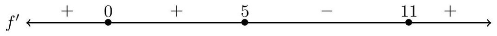

[figure not shown]

   The $f^{\prime}$ sign-line above shows that $f$ is increasing on the intervals $(-\infty, 0)$, $(0,5)$, and $(11, \infty)$, while $f$ is decreasing on $(5,11)$. Because $f$ is continuous, we conclude via the first-derivative test that $0$ yields neither a relative maximum nor a relative minimum of $f$, that $5$ yields a relative maximum, and that $11$ yields a relative minimum.
5. Find $f(x)$ given that $f^{\prime}(x)=3 x^{2}+4 x-1$ and $f(2)=9$.

   **Solution**: Antidifferentiating both sides of the equation $f^{\prime}(x)=3 x^{2}+4 x-1$, we find $f(x)=x^{3}+2 x^{2}-x+C$ for some constant $C$. Now, using $f(2)=9$, we obtain $9=14+C$, so that $C=-5$. Thus $f(x)=x^{3}+2 x^{2}-x-5$.
6. Find the area of the region bounded by the curves $y=4-x^{2}$ and $y=0$.

   **Solution**: The region whose area is to be computed is shaded in blue below.

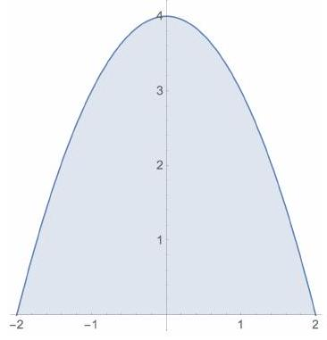

[figure not shown]

   The definite integral $\int_{-2}^{2}\left(4-x^{2}\right) d x$ yields the area:
   $$\int_{-2}^{2}\left(4-x^{2}\right) d x=\left[4 x-\frac{x^{3}}{3}\right]_{-2}^{2}=(8-8 / 3)-(-8+8 / 3)=\frac{32}{3}.$$
7. The number of items produced by a manufacturer is given by
   $$p=100 x y^{3},$$
   where $x$ is the amount of capital and $y$ is the amount of labor, amounts that change over time. At a particular point in time:
   1. the manufacturer has 2 units of capital;
   2. capital is increasing at a rate of 1 unit per month;
   3. the manufacturer has 3 units of labor; and
   4. labor is decreasing at a rate of $1 / 3$ unit per month.

   Determine the rate of change in the number of items produced at this point in time.

   **Solution**: Differentiating with respect to time we have
   $$\frac{d p}{d t}=100\left(x \cdot 3 y^{2} \frac{d y}{d t}+y^{3} \frac{d x}{d t}\right)$$
   At the moment when $x=2, \frac{d x}{d t}=1, y=3$ and $\frac{d y}{d t}=-1 / 3$, we have that
   $$\frac{d p}{d t}=100\left(2 \cdot 3 \cdot 3^{2} \cdot\left(\frac{-1}{3}\right)+3^{3} \cdot 1\right)=900 \text { items } / \text { month. }$$
8. Find $\int\left(e^{x}+1\right)^{2} d x$.

   **Solution**:
   $$\begin{aligned}
   \int\left(e^{x}+1\right)^{2} d x & =\int\left(e^{2 x}+2 e^{x}+1\right) d x \\
   & =\int e^{2 x} d x+2 \int e^{x} d x+\int 1 d x \\
   & =\frac{1}{2} \int e^{u} d u+2 e^{x}+x+C \quad\left(u=2 x ; \frac{1}{2} d u=d x\right) \\
   & =\frac{1}{2} e^{u}+2 e^{x}+x+C \\
   & =\frac{1}{2} e^{2 x}+2 e^{x}+x+C
   \end{aligned}$$
   Grade the problem "correct" even if you forgot to include $+C$.
9. Evaluate $\int_{e}^{e^{4}} \frac{1}{x \sqrt{\ln x}} d x$.

   **Solutions**: We have
   $$\begin{aligned}
   \int_{e}^{e^{4}} \frac{1}{x \sqrt{\ln x}} d x & =\int_{e}^{e^{4}}(\ln (x))^{-1 / 2} x^{-1} d x \\
   & =\int_{1}^{4} u^{-1 / 2} d u \quad\left(u=\ln x, d u=x^{-1} d x\right) \\
   & =\left[2 u^{1 / 2}\right]_{1}^{4} \\
   & =2(4)^{1 / 2}-2(1)^{1 / 2} \\
   & =2.
   \end{aligned}$$
10. Over the time interval $1 \leq t \leq 100$ the temperature of a freezer compartment is given by
    $$f(t)=\frac{t-4}{t^{2}},$$
    where $t$ is measured in hours and $f(t)$ is measured in degrees Celsius. What’s the maximum temperature of the freezer over this time interval?

    **Solution**: Because $f$ is continuous on $[1,100]$ (it’s a rational function whose domain includes the entire interval $[1,100]$), the Extreme-Value Theorem tell us that $f$ attains a maximum value at some number, say $c$, in $[1,100]$. This number $c$ must either be an endpoint of $[1,100]$ or a critical number of $f$ in $(1,100)$. We have
    $$f^{\prime}(t)=\frac{t^{2}(1)-(t-4) 2 t}{t^{4}}=\frac{8-t}{t^{3}},$$
    and thus $8$ is the only critical number of $f$ inside $(1,100)$. The largest of the three numbers $f(1), f(8), f(100)$ will be the maximum value of $f$ on $[1,100]$. Since $f(1)=-3, f(8)=1 / 16$, and $f(100)=96 / 10000< 100 / 10000=1 / 100$, we see the maximum temperature of the freezer over the time interval $[1,100]$ is $1 / 16$ degrees Celsius.